# Jovens do Brasil de 2015

Caracteristicas e situação de acordo com a PNAD 2015

Nabil Murtadha

2021

## Para essa análise utilizaremos os dados da PNAD Discreta do ano de 2015

O arquivo com as variaveis de interesse em formato `data.frame` e em formato expandida se encontra no meu [Github](https://github.com/nabilmurtadha/nabilmurtadha).

## Carregando PNAD 2015 e pacotes

```r
library(tidyverse)
library(srvyr)
library(survey)
options( survey.lonely.psu = "adjust" )
load(url("https://github.com/nabilmurtadha/nabilmurtadha/blob/main/pnad_2015.Rdata?raw=true"))
rm(pnad_2015t)
pnad_2015s <- srvyr::as_survey(pnad_2015s)
```

Primeiramente, apresentaremos as características médias do jovem brasileiro e do domicílio onde vive. Utilizaremos as fuções do pacote `srvy` pois permite uma manipulação similar ao `dplyr`, porém, mantendo os pesos da expanção.

### Criando o `data.frame` com as características básicas

```r
# gerando tabela
caracteristicas <- pnad_2015s %>%
  srvyr::filter(jovem == 1) %>%
  srvyr::mutate(anos_estudos = replace(as.numeric(anos_estudos), as.numeric(anos_estudos)==17, NA)-1,
                  escolaridade_chefe = replace(as.numeric(escolaridade_chefe), as.numeric(escolaridade_chefe) == 17,NA)-1) %>%
  srvyr::group_by(faixa_idade) %>%
  srvyr::summarise(feminino = srvyr::survey_mean(feminino ,vartype = "cv"), # mulher
                   branca = srvyr::survey_mean(branca ,vartype = "cv"),# raca cor branca
                   possui_filho = srvyr::survey_mean(possui_filho ,vartype = "cv"), # filho morando no domicilio (fem)
                   mora_c_pais = srvyr::survey_mean(mora_c_pais ,vartype = "cv"), # mora com os pais
                   atv_domestica = srvyr::survey_mean(atv_domestica , na.rm = T, vartype = "se"), # horas em atv domestica semanal de quem declarou
                   anos_estudos = srvyr::survey_mean(anos_estudos , na.rm = T,vartype = "se"), # anos de estudos
                   total_crianca = srvyr::survey_mean(total_crianca ,vartype = "se"), # qtd de criancas no domicilio
                   total_idoso = srvyr::survey_mean(total_idoso ,vartype = "se"), # qtd de idosos no domicilio
                   escolaridade_chefe = srvyr::survey_mean(escolaridade_chefe , na.rm = T, vartype = "se") # anos de estudo do chefe domicilio
                   )
```

### Verificando a distribuição do sexo, raça e se mora com os pais de acordo com a faixa etária.

```r
# Selecionando as colunas de interesse
caracteristicas %>% filter(!is.na(caracteristicas)) %>%
  select(faixa_idade,feminino,branca,mora_c_pais) %>%
  mutate_if(is.numeric, round, digits = 3) %>%
  knitr::kable()
```

| faixa_idade | feminino | branca | mora_c_pais |
| --- | --- | --- | --- |
| 16 a 18 anos | 0.489 | 0.401 | 0.801 |
| 19 a 21 anos | 0.490 | 0.411 | 0.674 |
| 22 a 24 anos | 0.493 | 0.426 | 0.540 |

Consideramos como jovens nessa análise pessoas entre 16 a 24 anos de idade. Abaixo dessa faixa etária a pessoa é classificada como criança e acima até os 69 anos de idade é considerado como adulto, de 70 acima será considerada como idosa. Percebemos que quanto mais velho menor a proporção dos jovens que moram com os pais.

### Verificando a escolaridade dos jovens

A coluna `anos_estudos` reflete a média de anos de estudo que os jovens possuem de acordo com a faixa de idade e a `escolaridade_chefe` reflete a média de anos de estudo do chefe do domicílio onde o jovem se encontra.

```r
# Selecionando as colunas de interesse
caracteristicas %>% filter(!is.na(caracteristicas)) %>%
  select(faixa_idade,anos_estudos,escolaridade_chefe) %>%
  mutate_if(is.numeric, round, digits = 3) %>%
  knitr::kable()
```

| faixa_idade | anos_estudos | escolaridade_chefe |
| --- | --- | --- |
| 16 a 18 anos | 8.571 | 7.137 |
| 19 a 21 anos | 9.876 | 7.492 |
| 22 a 24 anos | 10.267 | 8.001 |

A `escolaridade_chefe` aumenta de acordo com a faixa etária por que aumenta a probabilidade do jovem ser o chefe do domicílio, mas, ainda da pra perceber que a média é bem menor do que as dos jovens.

### Verificando quantidade média de criança e idoso no domicílio e afazeres domésticos.

A coluna `qtd_crianca` e `qtd_idoso` mostra a média de crianças e idosos em domicílios onde os jovens se encontra e a última coluna expressa em horas a média semanal em afazeres domésticos.

```r
# Selecionando as colunas de interesse
caracteristicas %>% filter(!is.na(caracteristicas)) %>%
  select(faixa_idade,qtd_criaca = total_crianca, qtd_idoso = total_idoso,afazeres_domesticos = atv_domestica) %>%
  mutate_if(is.numeric, round, digits = 3) %>%
  knitr::kable()
```

| faixa_idade | qtd_criaca | qtd_idoso | afazeres_domesticos |
| --- | --- | --- | --- |
| 16 a 18 anos | 0.921 | 0.081 | 13.284 |
| 19 a 21 anos | 0.737 | 0.080 | 15.059 |
| 22 a 24 anos | 0.717 | 0.079 | 16.560 |

Vemos que a composição da familia muda um pouco para a quantidade de criança se mais velho for o jovem, em relação aos idosos não muda muito e há um sutil aumento em torno de 1,5 hora semanal a mais em afazeres doméstico quanto mais velho for o jovem. Para a PNAD 2015, afazeres doméstico envolvem atividades de modo geral como: arrumar/limpar a casa, cozinhar, cuidar de filhos ou crianças e gerenciar trabalhadores domésticos. Normalmente atividades mais encarregadas para os jovens do sexo feminino.

# Situação dos jovens

Os jovens são pessoas entre 16 a 24 anos. Nessa apresentação, tentarei criar um panorama da relação dos jovens com os estudos e o mercado de trabalho. Com relação aos estudos, o jovem pode estar ou não frequentando a escola, já a relação com o mercado de trabalho o jovem pode estar ativo ou não. A pessoa que está ativa no mercado de trabalho tem que estar procurando emprego ou empregado, logo, faz parte da População Economicamente Ativa (PEA). Portanto,existem quatro possibilidades que o jovem pode se situar:

1. Somente estudando
2. Somente PEA
3. Estudando e PEA
4. Não Estudando e não PEA

Primeiramente, abaixo está as características médias da população jovem para que possamos comparar com a subpopulação referente a cada situação. Antes disso plotamos um gráfico boxplot para observarmos a distribuição da idade para cada grupo.

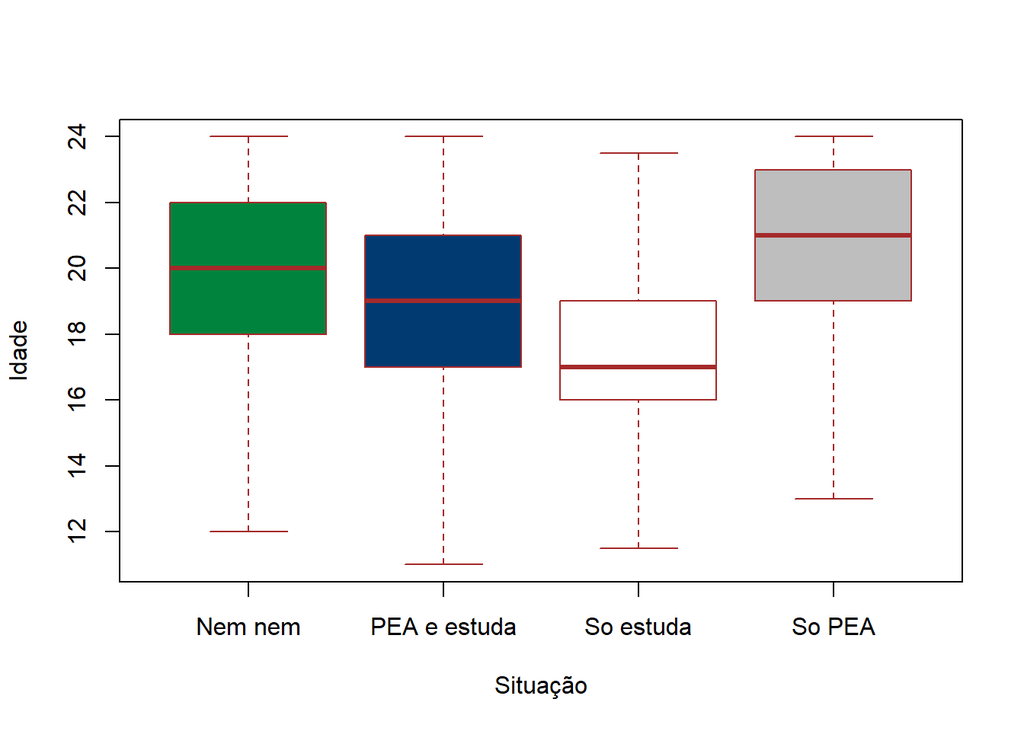

```r
svyboxplot(idade~sit, subset(pnad_2015s, jovem == 1),
           outline = F,
           xlab = "Situação",
           ylab = "Idade",
           col = c("#00843D","#003A70","white","grey"),
           border = "brown")
```

Percebemos que os jovens que só estudam costuma ser mais novos, os que só trabalham costumam ser mais velhos e os Nem-nem e os que trabalham e estudam entre os dois outros grupos.

### Proporções de sexo e raça e de acordo com a situação do jovem

```r
# Selecionando as colunas de interesse
caract_sit %>% filter(!is.na(caract_sit)) %>%
  select(Situacao = sit,feminino,branca,mora_c_pais) %>%
  mutate_if(is.numeric, round, digits = 3) %>%
  knitr::kable()
```

| Situacao | feminino | branca | mora_c_pais |
| --- | --- | --- | --- |
| Nem nem | 0.683 | 0.357 | 0.553 |
| PEA e estuda | 0.472 | 0.458 | 0.779 |
| So estuda | 0.541 | 0.441 | 0.830 |
| So PEA | 0.403 | 0.395 | 0.593 |

Verificamos então uma maior proporção de mulheres dentro do grupo dos Nem-nem. Em relação a raça todos os grupos são próximos da média populacional dos jovens, e em relação se mora ou não com os pais percebemos uma proporção baixa dos jovens que não estudam não estao ativos e para os jovens que só trabalham. Jovens que trabalham e estudam ou só estudam possuem uma maior proporção morando com os pais.

```r
# Selecionando as colunas de interesse
caract_sit %>% filter(!is.na(caract_sit)) %>%
  select(Situacao = sit,possui_filho) %>%
  mutate_if(is.numeric, round, digits = 3) %>%
  knitr::kable()
```

| Situacao | possui_filho |
| --- | --- |
| Nem nem | 0.340 |
| PEA e estuda | 0.038 |
| So estuda | 0.033 |
| So PEA | 0.131 |

Percebemos então que dentre os quatro tipos de situação, as mulheres Nem-nem são as que possuem maior percentual de filhos nascidos vivos e residente do mesmo domicílio. A tabela abaixo investiga a composição do domicílio e a quantida média de horas semanais gastas com afazeres domésticos para cada grupo.

```r
# Selecionando as colunas de interesse
caract_sit %>% filter(!is.na(caract_sit)) %>%
  select(Situacao = sit,qtd_criaca = total_crianca, qtd_idoso = total_idoso,afazeres_domesticos = atv_domestica) %>%
  mutate_if(is.numeric, round, digits = 3) %>%
  knitr::kable()
```

| Situacao | qtd_criaca | qtd_idoso | afazeres_domesticos |
| --- | --- | --- | --- |
| Nem nem | 1.059 | 0.082 | 22.552 |
| PEA e estuda | 0.705 | 0.084 | 11.778 |
| So estuda | 0.754 | 0.093 | 12.908 |
| So PEA | 0.769 | 0.071 | 14.297 |

### Relação entre anos de estudo e situação

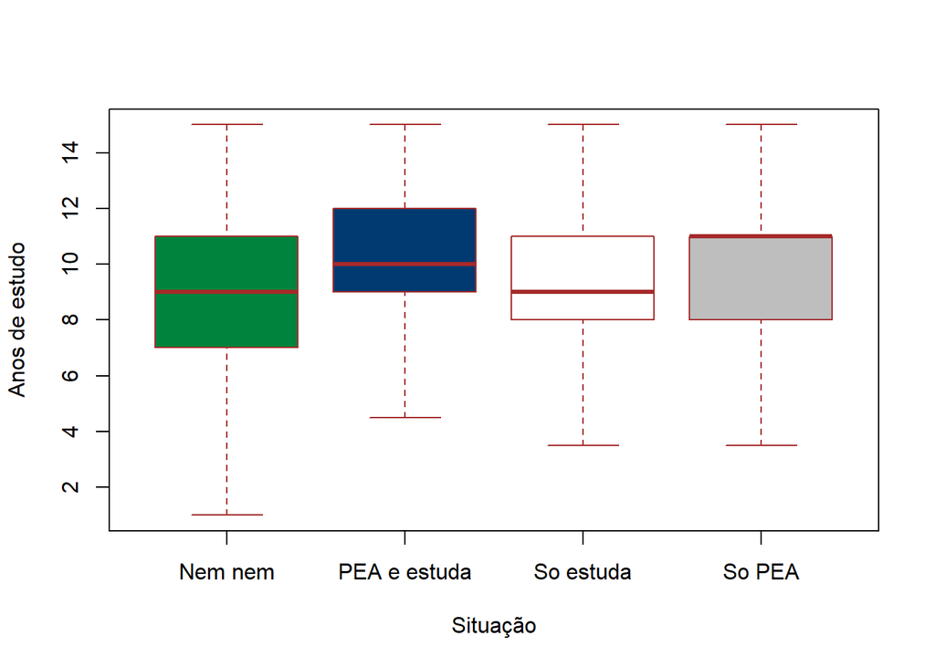

```r
pnad_2015s <- update(pnad_2015s,anos_estudo_corrigido = replace(as.numeric(anos_estudos), as.numeric(anos_estudos)==17, NA)-1)

svyboxplot(anos_estudo_corrigido~sit, subset(pnad_2015s, jovem == 1),
           outline = F,
           xlab = "Situação",
           ylab = "Anos de estudo",
           col = c("#00843D","#003A70","white","grey"),
           border = "brown")
```

O gráfico boxplot acima demonstra uma maior variação de anos de estudo dentre os jovens Nem-nem, e uma maior media para os outros grupos.

### Relação entre Renda domiciliar per capita e a situação do jovem

O gráfico abaixo demonstra a renda domiciliar para cada grupo.

Para plotarmos esse gráfico utilizaremos o pacote `survey` para mantermos a espansão da amostra e devido a disponibilidade do gráfico em `boxplot`.

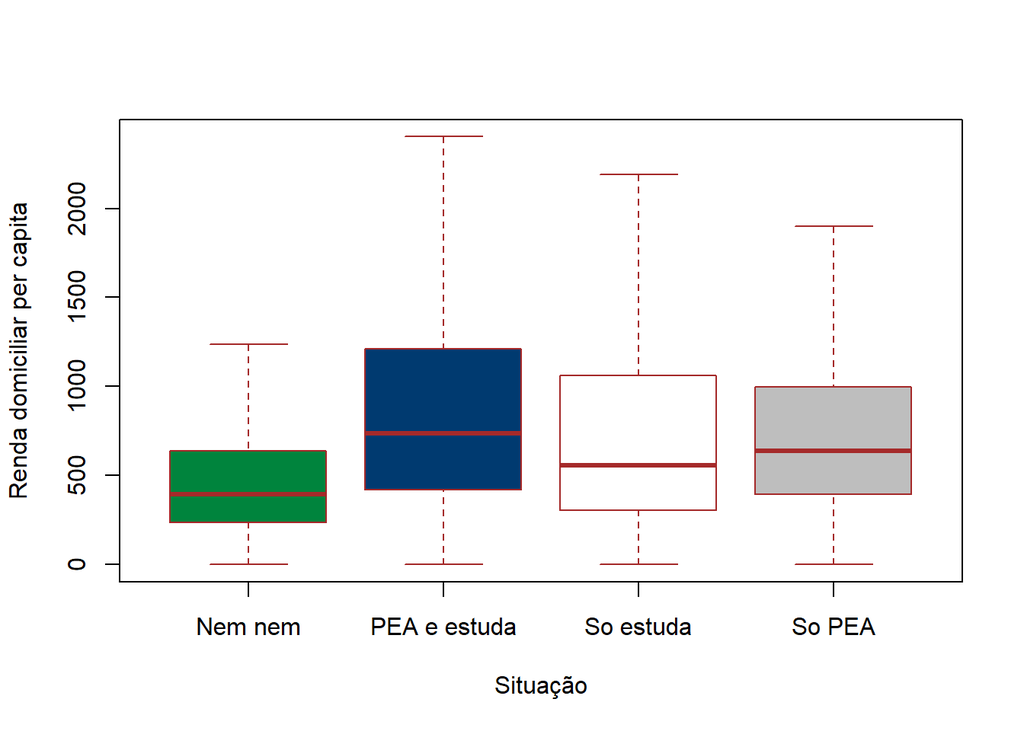

```r
svyboxplot(rdpc~sit, subset(pnad_2015s, jovem == 1),
           outline = F,
           xlab = "Situação",
           ylab = "Renda domiciliar per capita",
           col = c("#00843D","#003A70","white","grey"),
           border = "brown")
```

É notável que os jovens do Nem-nem possui a renda domiciliar per capita inferior aos outros grupos. E isso pode ser um dos motivos da sua sitaçao.

### Jovens Nem-nem

Para a regressão utilizaremos o pacote `survey`.

```r
probit <- svyglm(nn ~
                   feminino +
                   idade +
                   branca +
                   as.numeric(anos_estudos) +
                   as.numeric(escolaridade_chefe) +
                   mora_c_pais +
                   rdpc +
                   total_crianca +
                   total_idoso,
                   subset(pnad_2015s, jovem == 1), family = "binomial")


summary(probit)
```

```
##
## Call:
## svyglm(formula = nn ~ feminino + idade + branca + as.numeric(anos_estudos) +
##     as.numeric(escolaridade_chefe) + mora_c_pais + rdpc + total_crianca +
##     total_idoso, design = subset(pnad_2015s, jovem == 1), family = "binomial")
##
## Survey design:
## subset(pnad_2015s, jovem == 1)
##
## Coefficients:
##                                  Estimate Std. Error t value Pr(>|t|)
## (Intercept)                    -2.211e+00  1.256e-01 -17.605  < 2e-16 ***
## feminino                        1.078e+00  3.231e-02  33.369  < 2e-16 ***
## idade                           9.746e-02  5.878e-03  16.580  < 2e-16 ***
## branca                          2.738e-02  3.373e-02   0.812   0.4171
## as.numeric(anos_estudos)       -1.539e-01  6.065e-03 -25.376  < 2e-16 ***
## as.numeric(escolaridade_chefe) -1.044e-02  4.139e-03  -2.523   0.0117 *
## mora_c_pais                    -3.203e-01  3.200e-02 -10.008  < 2e-16 ***
## rdpc                           -4.487e-04  6.459e-05  -6.947 4.19e-12 ***
## total_crianca                   6.317e-02  1.421e-02   4.444 8.99e-06 ***
## total_idoso                     2.872e-02  4.683e-02   0.613   0.5398
## ---
## Signif. codes:  0 '***' 0.001 '**' 0.01 '*' 0.05 '.' 0.1 ' ' 1
##
## (Dispersion parameter for binomial family taken to be 4100.554)
##
## Number of Fisher Scoring iterations: 5
```

Percebemos com a regressão acima que a raça `branca` e a quantidade de idoso(`total_idoso`) no domicílio não influencia na probabilidade do jovem ser Nem-nem. Em relacão a escolaridade do chefe do domicílio há uma pequena significância e as outras variáveis como sexo `feminino`, `idade`, escolaridade do jovem (`anos_estudos`), `mora_c_pais`, `rdpc` e a quantidade de criança no domicílo (`total_crianca`) são significantes a 1%.

### Conclusão

O estudo acima demonstrou muito bem as características dos jovens de cada grupo. O que preocupa do ponto de vista econômico são os jovens Nem-nem que além de não estarem acumulando capital humano estão em condições de vulnerabilidade por que o resultado acima demonstrou uma baixa renda e baixa escolaridade para esse grupo, contribundo para o ciclo da pobreza. É necessário que governos deem atenção para esse grupo afim de promover o desenvolvimento humano e consequentemente o crescimento do país.